# Repeatability

## Repeatability of measurements

Parsing real variation vs. measurement error

How good are my observations?

1. Discrete measurements: **interrater reliability**
2. Continuous measurements: **intraclass correlation coefficient**

## Visualizing ANOVA

[figure not shown]

\[F = \frac{\mbox{Between Group Variation}}{\mbox{Within Group Variation}}\]

## Interrater reliability

How well do observers agree on an observation or categorization?

- Different observers (should be randomized and blinded)
- Same observer on different occasions (should be randomized and blinded; hours/days/weeks apart)

Measured by Cohen’s \(\kappa\). See Fleiss (1971) for details.

- Fleiss’s method generalizes Cohen’s method to more than two observers (but works fine for only two).

## Scoring archosaur suture morphology

[figure not shown]

From Bailleul et al. (2016)

## Characters

```r
M <- read_excel("../data/GatorObs.xlsx")
M %>% filter(Specimen == "MOR-OST-1645")
```

```
## # A tibble: 2 x 44
##   Observer Specimen   Ch1   Ch2   Ch3   Ch4   Ch5   Ch6   Ch7   Ch8   Ch9  Ch10
##      <dbl> <chr>    <dbl> <dbl> <dbl> <dbl> <dbl> <dbl> <dbl> <dbl> <dbl> <dbl>
## 1        1 MOR-OST…     5     5     1     0     1     0     1     0     1     0
## 2        2 MOR-OST…     5     5     1     0     2     0     2     0     2     0
## # … with 32 more variables: Ch11 <dbl>, Ch12 <dbl>, Ch13 <dbl>, Ch14 <dbl>,
## #   Ch15 <dbl>, Ch16 <dbl>, Ch17 <dbl>, Ch18 <dbl>, Ch19 <dbl>, Ch20 <dbl>,
## #   Ch21 <dbl>, Ch22 <dbl>, Ch23 <dbl>, Ch24 <dbl>, Ch25 <dbl>, Ch26 <dbl>,
## #   Ch27 <dbl>, Ch28 <dbl>, Ch29 <dbl>, Ch30 <dbl>, Ch31 <dbl>, Ch32 <dbl>,
## #   Ch33 <dbl>, Ch34 <dbl>, Ch35 <dbl>, Ch36 <dbl>, Ch37 <dbl>, Ch38 <dbl>,
## #   Ch39 <dbl>, Ch40 <dbl>, Ch41 <dbl>, Ch42 <dbl>
```

## Data wrangling

Extract observations as numeric vectors:

```r
Obs1 <- M %>%
  select(-Specimen) %>%
  filter(Observer == 1) %>%
  as.matrix() %>%
  as.numeric()
Obs2 <- M %>%
  select(-Specimen) %>%
  filter(Observer == 2) %>%
  as.matrix() %>%
  as.numeric()
```

## Data wrangling

Extract observations as numeric vectors:

```r
Obs1[1:20]
```

```
##  [1] 1 1 1 1 1 1 1 1 5 1 1 1 0 0 0 5 5 0 0 0
```

```r
Obs2[1:20]
```

```
##  [1] 2 2 2 2 2 2 2 2 5 2 1 1 0 1 0 5 5 0 0 0
```

## Calculating IRR with `CohenKappa()`

```r
library(DescTools)
CohenKappa(Obs1, Obs2, conf.level = 0.95)
```

```
##     kappa    lwr.ci    upr.ci
## 0.5982218 0.5309537 0.6654900
```

Arbitrary categorizations:

- Over 0.75 = excellent
- Between 0.75 and 0.4 = good to fair
- Less than 0.4 = poor

## Additional diagnostics

```r
cor.test(Obs1, Obs2, method = "spearman", exact = FALSE)
```

```
##
##  Spearman's rank correlation rho
##
## data:  Obs1 and Obs2
## S = 1763429, p-value < 2.2e-16
## alternative hypothesis: true rho is not equal to 0
## sample estimates:
##       rho
## 0.7400813
```

```r
sum(Obs1 != Obs2) / length(Obs1) # Percent disagreement
```

```
## [1] 0.2848837
```

## Intraclass Correlation Coefficient

For continuously varying measurements:

\[\mbox{ICC} =\frac{\sigma_{A}^{2}}{\sigma_{A}^{2}+MS_{error}}\]

\[\sigma_{A}^{2}=\frac{MS_{group}-MS_{error}}{n}\]

- \(n\) = Number of measurements per specimen (*not the sample size*).

Uses the results of the linear model (ANOVA):

\[\mbox{Measurement} \sim \mbox{Specimen ID}\]

## Repeatability of lipid levels in the same sample

[figure not shown]

## Calculation of ICC

What is the ICC of repeated measurements of lipid levels in fruit flies?

```r
M <- read_csv("../data/macromol_optim.csv") %>%
  mutate(replicate = rep(paste0("rep",c(1,2)),439),
         Line = factor(Line))
glimpse(M)
```

```
## Rows: 878
## Columns: 7
## $ Line          <fct> 100C, 100C, 100DR, 100DR, 100HS, 100HS, 101C, 101C, 101…
## $ WellC         <chr> "B4", "B9", "C4", "C9", "A4", "A9", "F2", "F7", "F3", "…
## $ PLATE         <chr> "LAMBDA2", "LAMBDA2", "LAMBDA2", "LAMBDA2", "LAMBDA2", …
## $ RIL           <dbl> 100, 100, 100, 100, 100, 100, 101, 101, 101, 101, 101, …
## $ Treat         <chr> "C", "C", "DR", "DR", "HS", "HS", "C", "C", "DR", "DR",…
## $ Lipid.per.Fly <dbl> 0.7725609, 0.5972415, 0.4970590, 0.4219221, 0.8414364, …
## $ replicate     <chr> "rep1", "rep2", "rep1", "rep2", "rep1", "rep2", "rep1",…
```

## Pairs of measurements

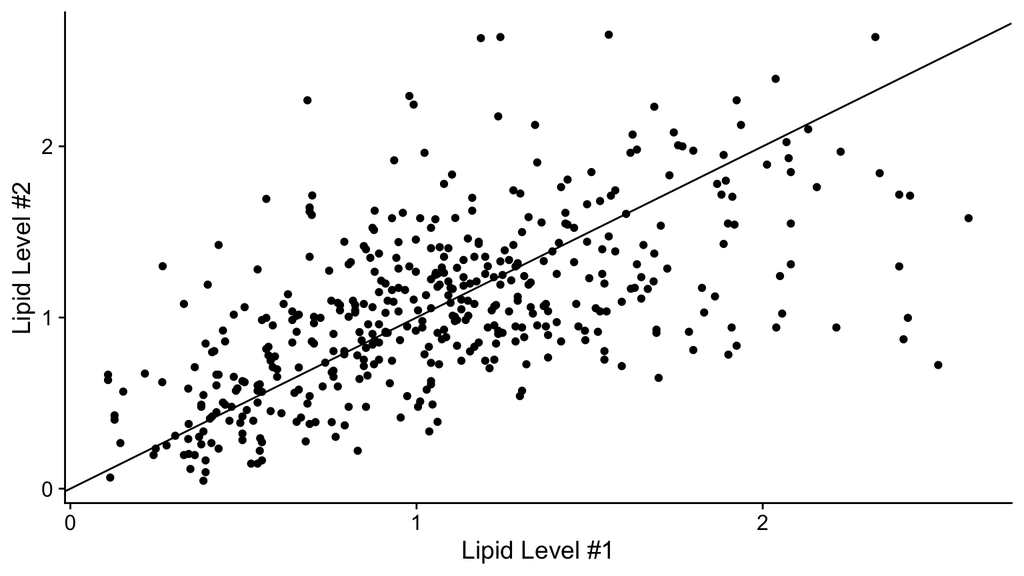

## ICC via ANOVA

```r
fm <- aov(Lipid.per.Fly ~ Line, data = M)
print(summary(fm), digits = 5)
```

```
##              Df  Sum Sq Mean Sq F value    Pr(>F)
## Line        438 173.433 0.39597   3.946 < 2.2e-16 ***
## Residuals   439  44.052 0.10035
## ---
## Signif. codes:  0 '***' 0.001 '**' 0.01 '*' 0.05 '.' 0.1 ' ' 1
```

```r
var_a <- (0.39597 - 0.10035) / 2
var_a / (var_a + 0.10035)
```

```
## [1] 0.5956238
```

ICC is 0.60 for these measurements.

## With `ICCest()`

```r
library(ICC)
ICCest(Line,
       Lipid.per.Fly,
       data = M,
       alpha = 0.05,
       CI.type = "Smith")
```

## With `ICCest()`

```
## $ICC
## [1] 0.5956351
##
## $LowerCI
## [1] 0.5352444
##
## $UpperCI
## [1] 0.6560259
##
## $N
## [1] 439
##
## $k
## [1] 2
##
## $varw
## [1] 0.1003453
##
## $vara
## [1] 0.14781
```

## Additional utility functions in `ICC` package

`Nest()`: Given a predicted ICC and *k* measures per individual/group, this function will calculate the *N* individuals/groups required to obtain a desired confidence interval

`effort()`: Given a fixed researcher effort (e.g., total number of assays able to be run), this function plots the optimum *k* measurements per individual to use in order to obtain the smallest confidence interval at an expected intraclass correlation coefficient (ICC) estimate.

## References

Bailleul, A. M., J. B. Scannella, J. R. Horner, and D. C. Evans. 2016. Fusion Patterns in the Skulls of Modern Archosaurs Reveal That Sutures Are Ambiguous Maturity Indicators for the Dinosauria. *PLoS One* 11:e0147687.

Fleiss, J. L. 1971. Measuring Nominal Scale Agreement Among Many Raters. *Psychol. Bull.* 76:378–382.